# Bayesian classification and discriminant factor analysis

YICHEN_LI

# 1.Introduction

In recent years, the application of AI-generated text has made significant progress, from natural language processing (NLP) models to large language models (such as GPT), which not only promotes the development of text generation technology, but also brings unprecedented convenience to content creation, education, and even daily communication. However, the rapid popularity of this technology has also raised concerns about its misuse, such as generating false information, plagiarism, or academic cheating. Therefore, how to accurately detect AI-generated text has become an important research direction and technical challenge. The solution of this problem is not only crucial for the maintenance of the authenticity of the content, but also provides a technical guarantee for the protection of academic and intellectual property rights.

The goal of this project is to develop an efficient and accurate AI text detection model using Bayesian classification and discriminant factor analysis methods. Bayesian classification captures the latent features of texts through probabilistic inference models, while discriminant factor analysis further analyzes and distinguishes the key features of different categories of texts, thereby improving the accuracy of detection.

# 2.Data & Preprocessing

## 2.1 Data loading

```r
options(warn = -1)

suppressWarnings({
    library(readxl)
    library(dplyr)
    library(tm)
    library(text2vec)
    library(brms)
    library(ROCR)
    library(ggplot2)
    library(irlba)
    library(caret)
    library(klaR)
    library(MASS)
    library(MLmetrics)
})
```

```
## Loading 'brms' package (version 2.22.0). Useful instructions
## can be found by typing help('brms'). A more detailed introduction
## to the package is available through vignette('brms_overview').
```

```r
train_essays_path <- "/Users/lyly/R_project_DSIA_YICHEN_LI/final_datasets/llm-detect-ai-generated-text/train_essays.xlsx"
test_essays_path <- "/Users/lyly/R_project_DSIA_YICHEN_LI/final_datasets/llm-detect-ai-generated-text/test_essays.xlsx"
train_drcat_paths <- c("/Users/lyly/R_project_DSIA_YICHEN_LI/final_datasets/train_drcat_01/train_drcat_01.xlsx",
                       "/Users/lyly/R_project_DSIA_YICHEN_LI/final_datasets/train_drcat_02/train_drcat_02.xlsx",
                       "/Users/lyly/R_project_DSIA_YICHEN_LI/final_datasets/train_drcat_03/train_drcat_03.xlsx",
                       "/Users/lyly/R_project_DSIA_YICHEN_LI/final_datasets/train_drcat_04/train_drcat_04.xlsx")

save_path <- "/Users/lyly/R_project_DSIA_YICHEN_LI/final_datasets/results"
```

```r
# Load the data and convert to data.frame format
train_essays <- as.data.frame(read_excel(train_essays_path))
test_essays <- as.data.frame(read_excel(test_essays_path))
suppressWarnings(
  train_drcat <- bind_rows(lapply(train_drcat_paths, function(path) {
    as.data.frame(read_excel(path))
  }))
)
```

## 2.3 Data cleansing

```r
# Clean up column names: Convert all column names to lowercase and replace special characters
colnames(train_essays) <- tolower(gsub("\\s+|\\n|\\t", "_", colnames(train_essays)))
colnames(train_drcat) <- tolower(gsub("\\s+|\\n|\\t", "_", colnames(train_drcat)))
colnames(test_essays) <- tolower(gsub("\\s+|\\n|\\t", "_", colnames(test_essays)))

# Verify that the column names contain 'text' and 'label', and keep the necessary columns
train_essays <- train_essays[, c("text", "label")]
train_drcat <- train_drcat[, c("text", "label")]

# Make sure the 'label' column is numeric
train_essays$label <- as.numeric(train_essays$label)
train_drcat$label <- as.numeric(train_drcat$label)

test_essays <- test_essays[, c("text")]

# Only data with values of 0 and 1 in the label column is retained
train_essays <- train_essays %>%
  filter(label %in% c(0, 1))

train_drcat <- train_drcat %>%
  filter(label %in% c(0, 1))

# Merge training data
combined_train <- bind_rows(train_essays, train_drcat)
combined_train <- as.data.frame(combined_train)

# Make sure the label column is the factor type
combined_train <- combined_train %>%
  mutate(label = as.factor(label))
```

## 2.4 EDA

### 2.4.1 Basic Information

```r
# View the basic structure of the data frame
str(combined_train)
```

```
## 'data.frame':    160727 obs. of  2 variables:
##  $ text : chr  "Cars. Cars have been around since they became famous in the 1900s, when Henry Ford created and built the first "| __truncated__ "Transportation is a large necessity in most countries worldwide. With no doubt, cars, buses, and other means of"| __truncated__ "\"America's love affair…
##  $ label: Factor w/ 2 levels "0","1": 1 1 1 1 1 1 1 1 1 1 ...
```

```r
# View summary statistics for a dataset
summary(combined_train)
```

```
##      text           label
##  Length:160727      0:116722
##  Class :character   1: 44005
##  Mode  :character
```

```r
# Check if there are any missing values
cat("The number of missing values:\n")
```

```
## The number of missing values:
```

```r
print(colSums(is.na(combined_train)))
```

```
##  text label
##     0     0
```

```r
# Check the distribution of the 'label' column
cat("Label distribution:\n")
```

```
## Label distribution:
```

```r
table(combined_train$label)
```

```
##
##      0      1
## 116722  44005
```

There are a total of 160,727 records in the dataset, including the text and label columns. The text column is a character that records the specific text content, while the label column is a factor, divided into two categories: 0 and 1. The label distribution showed that there were 116,722 samples in class 0, accounting for 72.6% of the total samples, while there were 44,005 samples in class 1, accounting for 27.4%, and there was a certain imbalance. There are no missing values in the data, and the data quality is high.

### 2.4.2 A map of the distribution of text lengths

```r
# Calculate the length (number of characters) of each piece of text
combined_train$text_length <- nchar(combined_train$text)
summary(combined_train$text_length)
```

```
##    Min. 1st Qu.  Median    Mean 3rd Qu.    Max.
##     239    1511    2036    2225    2663   18318
```

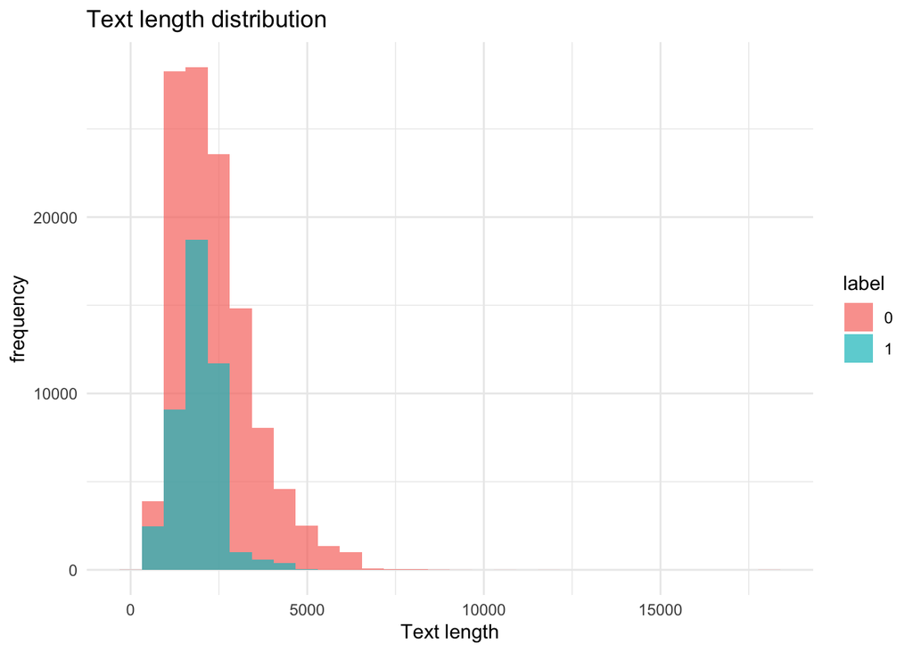

```r
# Draw a map of the distribution of text lengths
library(ggplot2)
ggplot(combined_train, aes(x = text_length, fill = label)) +
  geom_histogram(bins = 30, alpha = 0.7, position = "identity") +
  labs(title = "Text length distribution", x = "Text length", y = "frequency") +
  theme_minimal()
```

**Data distribution analysis**

The distribution of text length is generally skewed to the right, with most text lengths concentrated between 500 and 4000, and the sample size gradually decreases as the text length increases, with very few text lengths exceeding 10000. The five-digit statistic shows a minimum length of 239, a median of 2036, and a maximum of 18318. The average length is 2225, indicating that there is some extremely long text that pulls up the mean.

## 2.5 Text preprocessing

Normalize test data test_essays to a data frame format and perform uniform cleansing operations on text in both the training and test sets, including lowercase, removal of punctuation and numbers, and removal of extra whitespace to ensure data consistency and reduce noise.

```r
if (is.vector(test_essays)) {
  test_essays <- data.frame(text = test_essays, stringsAsFactors = FALSE)
}

# Text cleanup function
clean_text <- function(text) {
  text %>%
    tolower() %>%
    removePunctuation() %>%
    removeNumbers() %>%
    stripWhitespace()
}

combined_train$text <- sapply(combined_train$text, clean_text)
test_essays$text <- sapply(test_essays$text, clean_text)
```

# 3.Feature extraction: TF-IDF

Feature engineering text data. Reduce noise and extraneous features by limiting the size of the vocabulary and removing low-frequency words and words with a high document ratio. The vocabulary vectorizer is used to convert the cleaned text into a sparse document-word matrix (DTM), and the TF-IDF method is used to calculate the feature weights and retain the sparse format, so as to extract features that can better reflect the importance of the text.

```r
# Limit vocabulary size and discard low-frequency words
vocab <- create_vocabulary(itoken(combined_train$text, progressbar = FALSE))
pruned_vocab <- prune_vocabulary(vocab, term_count_min = 5, doc_proportion_max = 0.5)
vectorizer <- vocab_vectorizer(pruned_vocab)

# Create a Sparse Document - Word Matrix (DTM)
train_dtm <- create_dtm(itoken(combined_train$text, progressbar = FALSE), vectorizer)

# Calculate TF-IDF Feature Matrix (Keep Sparse Format)
tfidf <- TfIdf$new()
tfidf_matrix <- fit_transform(train_dtm, tfidf)
```

# 4.Discriminant factor analysis

The truncated SVD method was used to reduce the dimensionality of the TF-IDF feature matrix, and the 100 most representative features were extracted. By truncating the left singular matrix (U matrix) of the SVD as the dimensionality reduction feature, the label information is retained to reduce memory usage. Ensure feature simplification without losing important information about the classification task.

```r
# Use Truncated SVD to reduce the dimensionality of sparse matrices
set.seed(123)
svd_result <- irlba(tfidf_matrix, nv = 100)  # nv is the number of features after dimensionality reduction, and 100 features are selected

# The U-matrix of the SVD (the left singular matrix) is taken as the dimensionality reduction feature
reduced_features <- as.data.frame(svd_result$u)

reduced_features$label <- combined_train$label
reduced_features$label <- as.factor(reduced_features$label)
```

In order to further extract the category discriminant features, linear discriminant analysis (LDA) was applied to the reduced data. Through the LDA method, the features are transformed into discriminative features that can maximize the differentiation of label categories while maintaining the consistency of label information

```r
# Perform discriminant factor analysis (LDA)
lda_result <- lda(label ~ ., data = reduced_features, prior = c(0.5, 0.5))

# Use LDA to transform features
lda_transformed <- as.data.frame(predict(lda_result)$x)
lda_transformed$label <- reduced_features$label

lda_transformed$label <- factor(lda_transformed$label, levels = unique(lda_transformed$label), labels = make.names(levels(lda_transformed$label)))
```

# 5.Bayesian classification

The model is evaluated with hierarchical k-fold cross-validation, and a 5-fold cross-validation is set to ensure the robustness of the training process. On the basis of dimensionality reduction and discriminant feature extraction, the naïve Bayesian classification model is used for training, and the final prediction results and category probabilities are saved.

```r
# Set the layered k-fold cross-validation parameters
set.seed(123)
train_control <- trainControl(
  method = "cv",
  number = 5,
  savePredictions = "final",
  classProbs = TRUE,
  summaryFunction = multiClassSummary
)

# Train the Naive Bayes model
nb_model <- train(
  label ~ .,
  data = lda_transformed,
  method = "nb",
  trControl = train_control
)

print(nb_model)
```

```
## Naive Bayes
##
## 160727 samples
##      1 predictor
##      2 classes: 'X0', 'X1'
##
## No pre-processing
## Resampling: Cross-Validated (5 fold)
## Summary of sample sizes: 128582, 128582, 128581, 128582, 128581
## Resampling results across tuning parameters:
##
##   usekernel  logLoss     AUC        prAUC      Accuracy   Kappa      F1
##   FALSE      0.06915827  0.9949856  0.9868927  0.9785786  0.9460543  0.9852639
##    TRUE      0.06424501  0.9950578  0.9939780  0.9790950  0.9470804  0.9856640
##   Sensitivity  Specificity  Pos_Pred_Value  Neg_Pred_Value  Precision
##   0.9861123    0.9585956    0.9844173       0.9629971       0.9844173
##   0.9895992    0.9512328    0.9817603       0.9718178       0.9817603
##   Recall     Detection_Rate  Balanced_Accuracy
##   0.9861123  0.7161273       0.972354
##   0.9895992  0.7186596       0.970416
##
## Tuning parameter 'fL' was held constant at a value of 0
## Tuning
##  parameter 'adjust' was held constant at a value of 1
## Accuracy was used to select the optimal model using the largest value.
## The final values used for the model were fL = 0, usekernel = TRUE and adjust
##  = 1.
```

In the process of training the naïve Bayes classifier, cross-validation was used to evaluate the performance of the model, and the results showed that the overall performance of the model was excellent. When kernel density estimation (usekernel = TRUE) is enabled, the accuracy of the model reaches 0.9791 and the AUC value is 0.9950, indicating that the model is very capable of distinguishing between positive and negative samples. At the same time, the precision and recall rates were 0.9818 and 0.9896, respectively, indicating that the model performed stably in detecting the target category. In addition, the logLoss value is reduced to 0.0642, proving that the model is more reliable in predicting categorical probabilities.

# 6.Evaluation & Results

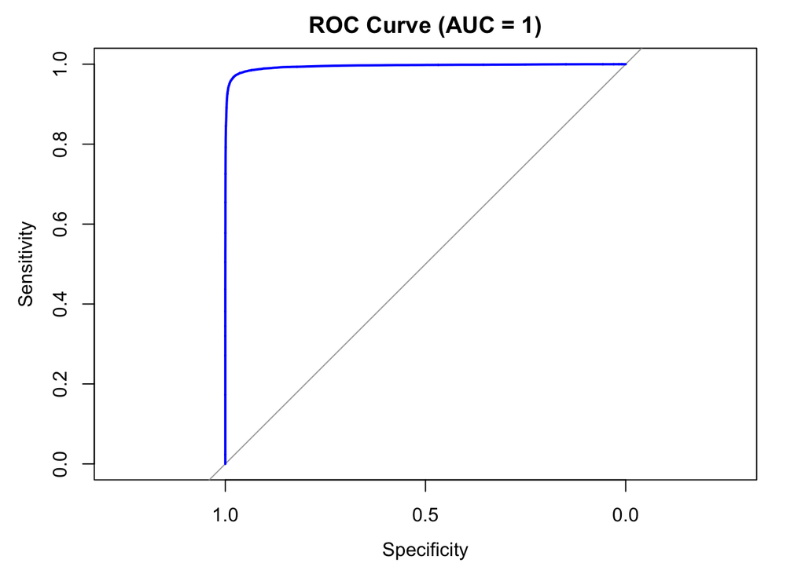

```r
# Extract cross-validation predictions
predictions <- nb_model$pred

# Extract probabilities for class "X1"
prob_values <- predictions$X1

# Convert `obs` to numeric (0 and 1)
obs_numeric <- as.numeric(predictions$obs) - 1  # Convert factor to 0 and 1

# Calculate ROC curve and AUC
library(pROC)
roc_curve <- roc(obs_numeric, prob_values)
# Plot ROC curve
plot(
  roc_curve,
  col = "blue",
  main = paste("ROC Curve (AUC = ", round(auc(roc_curve), 2), ")", sep = "")
)
```

```r
# Output AUC value
cat("AUC value:", auc(roc_curve), "\n")
```

```
## AUC value: 0.9950066
```

```r
# Confusion matrix: calculate accuracy, precision, recall, and F1 score
conf_matrix <- confusionMatrix(predictions$pred, predictions$obs)
print(conf_matrix)
```

```
## Confusion Matrix and Statistics
##
##           Reference
## Prediction     X0     X1
##         X0 115508   2146
##         X1   1214  41859
##
##                Accuracy : 0.9791
##                  95% CI : (0.9784, 0.9798)
##     No Information Rate : 0.7262
##     P-Value [Acc > NIR] : < 2.2e-16
##
##                   Kappa : 0.9471
##
##  Mcnemar's Test P-Value : < 2.2e-16
##
##             Sensitivity : 0.9896
##             Specificity : 0.9512
##          Pos Pred Value : 0.9818
##          Neg Pred Value : 0.9718
##              Prevalence : 0.7262
##          Detection Rate : 0.7187
##    Detection Prevalence : 0.7320
##       Balanced Accuracy : 0.9704
##
##        'Positive' Class : X0
##
```

```r
# Extract metrics
accuracy <- conf_matrix$overall["Accuracy"]
precision <- conf_matrix$byClass["Pos Pred Value"]
recall <- conf_matrix$byClass["Sensitivity"]
f1_score <- 2 * (precision * recall) / (precision + recall)

cat("Accuracy:", accuracy, "\n")
```

```
## Accuracy: 0.979095
```

```r
cat("Precision:", precision, "\n")
```

```
## Precision: 0.9817601
```

```r
cat("Recall:", recall, "\n")
```

```
## Recall: 0.9895992
```

```r
cat("F1 Score:", f1_score, "\n")
```

```
## F1 Score: 0.9856641
```

The AUC value of the ROC curve is 0.9950, which is close to 1, indicating that the model is very good at distinguishing between positive and negative samples. The confusion matrix showed that the accuracy of the model was 97.91%, and the Kappa value was 0.9471, which further verified the consistency and robustness of the model classification. In terms of specific indicators of classification, the precision of the model for the positive class (X0) is 98.18%, the recall rate is 98.96%, and the F1 score reaches 98.57%, which shows that the model has taken into account high accuracy and recall ability on the basis of high accuracy.

Looking at the confusion matrix, 1214 samples labeled X0 were misclassified as X1, and 2146 samples labeled X1 were misclassified as X0. Although the number of misclassifications was relatively small, the specificity was 95.12%, which was slightly lower than the sensitivity (98.96%), indicating that the model was slightly weaker than the positive class (X0) when detecting negative (X1) samples. Overall, the Balanced Accuracy was 97.04%, indicating that the model could maintain classification performance well despite the category imbalance.